# 📈 Forecasting Food Retail Turnover in Western Australia

## 13.1 📊 2-Year Forecast (Test Set)

```r
retail_test_ets <- retail_ets_fit |>
  forecast(h = "2 years")

retail_test_ets
```

```
## # A fable: 96 x 6 [1M]
## # Key:     State, Industry, .model [4]
##    State             Industry       .model    Month           Turnover .mean
##    <chr>             <chr>          <chr>     <mth>             <dist> <dbl>
##  1 Western Australia Food retailing ets    2021 Jan t(N(7.3, 0.00082)) 1427.
##  2 Western Australia Food retailing ets    2021 Feb t(N(7.2, 0.00091)) 1352.
##  3 Western Australia Food retailing ets    2021 Mar   t(N(7.3, 0.001)) 1477.
##  4 Western Australia Food retailing ets    2021 Apr  t(N(7.3, 0.0011)) 1419.
##  5 Western Australia Food retailing ets    2021 May  t(N(7.3, 0.0012)) 1437.
##  6 Western Australia Food retailing ets    2021 Jun  t(N(7.2, 0.0013)) 1384.
##  7 Western Australia Food retailing ets    2021 Jul  t(N(7.3, 0.0014)) 1431.
##  8 Western Australia Food retailing ets    2021 Aug  t(N(7.3, 0.0016)) 1452.
##  9 Western Australia Food retailing ets    2021 Sep  t(N(7.3, 0.0017)) 1430.
## 10 Western Australia Food retailing ets    2021 Oct  t(N(7.3, 0.0018)) 1497.
## # ℹ 86 more rows
```

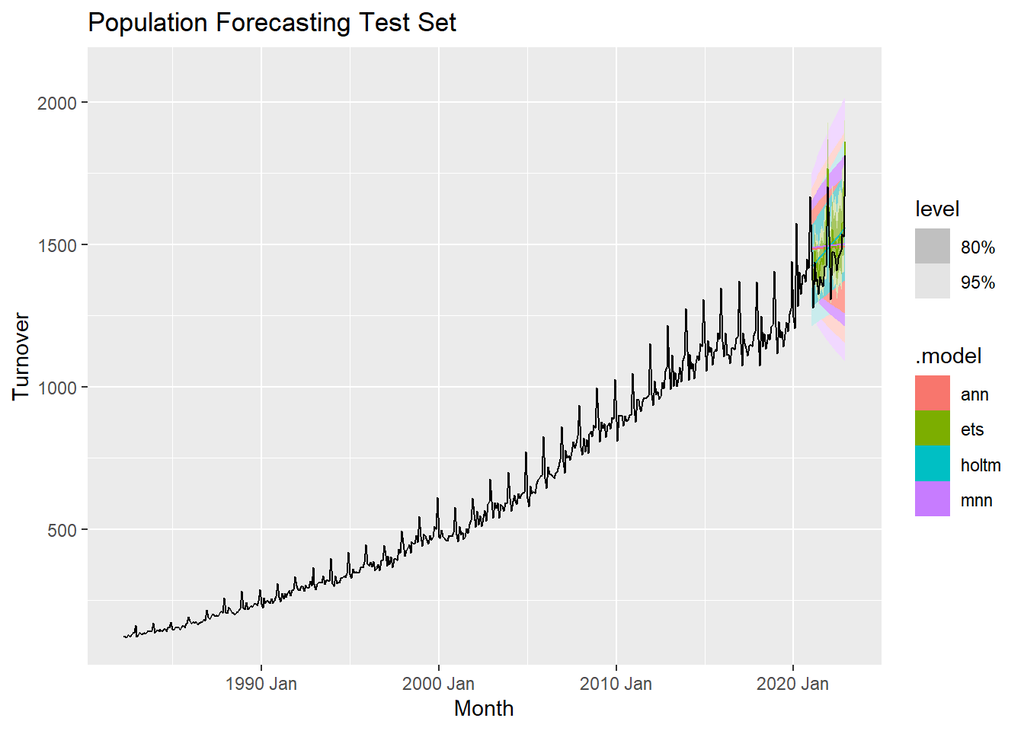

```r
retail_test_ets |>
  autoplot(retail) +
  labs(title = "Population Forecasting Test Set")
```

- The forecast plot for the test set shows predictions from four ETS models (ann, ets, holtm, mnn) for food retailing turnover in Western Australia. The `ets` model, indicated in green, aligns closely with the observed data, suggesting accurate forecasting. Prediction intervals at 80% and 95% confidence levels are shown, with the `ets` model providing the tightest intervals, indicating higher forecast confidence compared to the other models.